# Profile of Ford GoBike Rentals at Busiest Start Stations

### by Phyllis La Monica

## Investigation Overview

This investigation looks at 2018 rental data with a specific focus on the origination point of rentals.

My primary interest was to look at the characteristics of rentals at the 5 busiest start_stations. A preliminary look at the data suggested younger male subscribers would be the majority of renters. Information on the rental characteristics explored in this investigation, gender, user type, age and rental day, could be put to use by GoBike system administrators and marketers.

## Dataset Overview

The Ford GoBike System is a regional bike sharing system for the public. It covers the greater San Francisco Bay area in California. A master dataset, created by merging 12 months of data, was refined to include rental information for only the 5 busiest start stations. This data was further refined to include only renters from age 14 to 80. This step eliminated outliers, necessary as the original age range of 0 to 130 clearly included non-living renters.

Four characteristics were investigated: gender, user type, age and rental day. The resulting dataframe includes information on 168,373 rentals. A further breakdown of the rental characteristics:

## Distribution of Gender Split by User Type

The vast majority of renters at the 5 busiest start station are clearly male subscribers. Given the 3 to 1 proportion of males to the other 2 genders, female and others, this is not difficult to understand. What is not clear is why there are so many more male GoBike renters, an explanation not to be found in the available data.

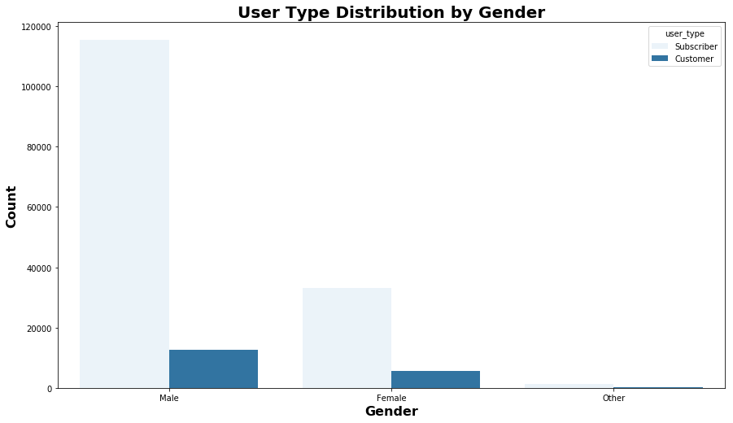

```python
# Set plot dimension
plt.figure(figsize=[14.70, 8.27])

# Distribution: count by gender split by user type
base_color = sb.color_palette()[0]
sb.countplot(x='member_gender',hue='user_type', data=df_age_busy, color=base_color).set_title('User Type Distribution by Gender', fontsize = 20, weight = 'semibold')
plt.xlabel('Gender', fontsize = 16, weight = 'semibold')
plt.ylabel('Count', fontsize = 16, weight = 'semibold');
```

## Gender and User Type by Day of Rental

The second visualization iterates the extremes in the distribution of gender counts over rental days. Both plots suggest that male subscribers use GoBikes for transport back and forth to work on the weekdays.

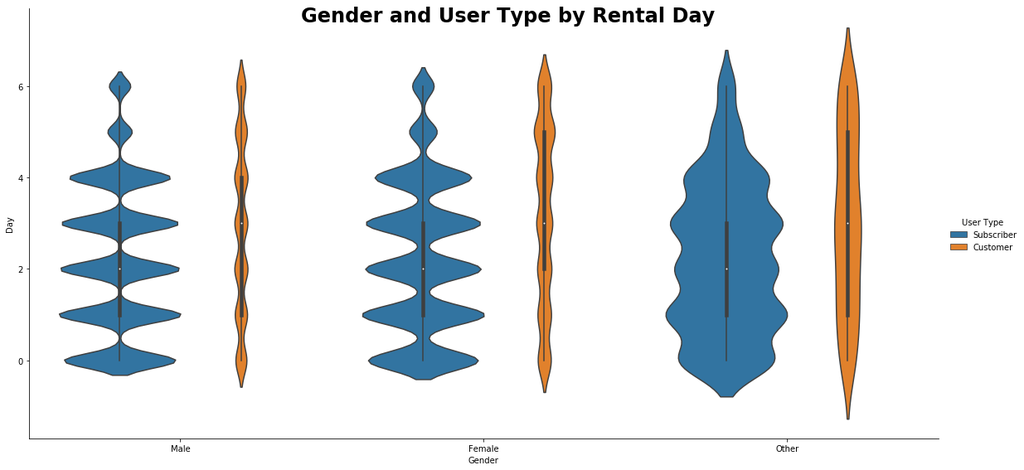

```python
# Look at gender and user type on day of rental

g = sb.catplot(data=df_age_busy, x='member_gender', y='day_started', hue='user_type', kind="violin", height=8, aspect=2, scale='count');

g._legend.set_title('User Type ')
g.set_axis_labels('Gender', 'Day')
g.fig.suptitle('Gender and User Type by Rental Day',  fontsize = 24, weight = 'semibold');

plt.show()
plt.close(1); # needed to avoid appearance of empty grid
```

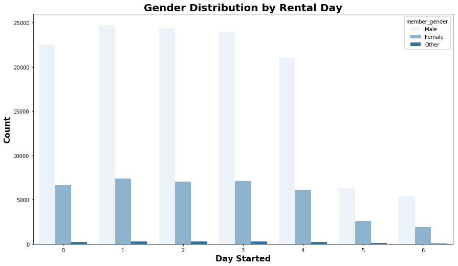

```python
# Set plot dimension
plt.figure(figsize=[14.70, 8.27])

# Distribution: count by gender for rental day
base_color = sb.color_palette()[0]
sb.countplot(x='day_started',hue='member_gender', data=df_age_busy, color=base_color).set_title('Gender Distribution by Rental Day', fontsize = 20, weight = 'semibold')
plt.xlabel('Day Started', fontsize = 16, weight = 'semibold')
plt.ylabel('Count', fontsize = 16, weight = 'semibold');
```

## Interaction of Gender and User Type over Age

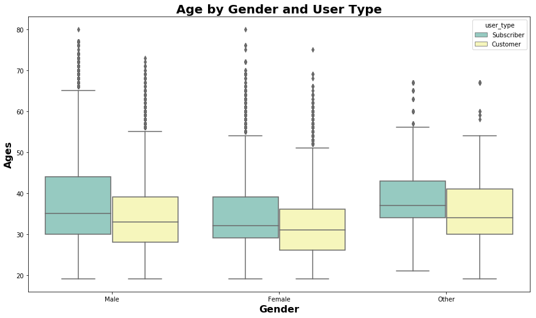

```python
# Set plot dimension, comment out figsize
plt.figure(figsize=[14.70, 8.27]);

# Look at plots for categorical values and day_started for busiest stations
#fig, ax = plt.subplots(figsize = [14,6]);
sb.boxplot(data=df_age_busy, x='member_gender', y='age', hue='user_type', palette='Set3').set_title('Age by Gender and User Type',fontsize = 20, weight = 'semibold')
plt.ylabel('Ages', fontsize = 16, weight = 'semibold')
plt.xlabel('Gender', fontsize = 16, weight = 'semibold');
```